# INSA - Series Temporais

Diana Vieira Fernandes

5/28/2019

## Análise de Séries Temporais em Saúde Pública

## Packages

ISOweek url: https://cran.r-project.org/web/packages/ISOweek/ISOweek.pdf

Series temporais em Saude Publica

28 e 29 de maio de 2019

##### Modelo Linear aplicado a mortalidade diaria

Onda de calor de 1991

dados entre 1989 e 1993

# Definir directoria do trabalho

```r
setwd("~/Desktop/INSA")
```

# Ler o ficheiro de dados formato .csv

```r
dados <- read.csv("Portugal_GC_CR.csv", header = T, sep = ";")
str(dados)
```

```
## 'data.frame':    12054 obs. of  3 variables:
##  $ Data    : Factor w/ 12054 levels "01-01-1980","01-01-1981",..: 1 397 793 1189 1585 1981 2377 2773 3169 3565 ...
##  $ Total   : int  387 340 312 278 258 301 298 302 331 281 ...
##  $ CircResp: int  186 166 180 153 132 164 166 156 170 136 ...
```

# so precisamos corrigir a variavel Data para o tipo Data

```r
dados$Data <- as.Date(dados$Data,format="%d-%m-%Y")
```

# Ver a série temporal

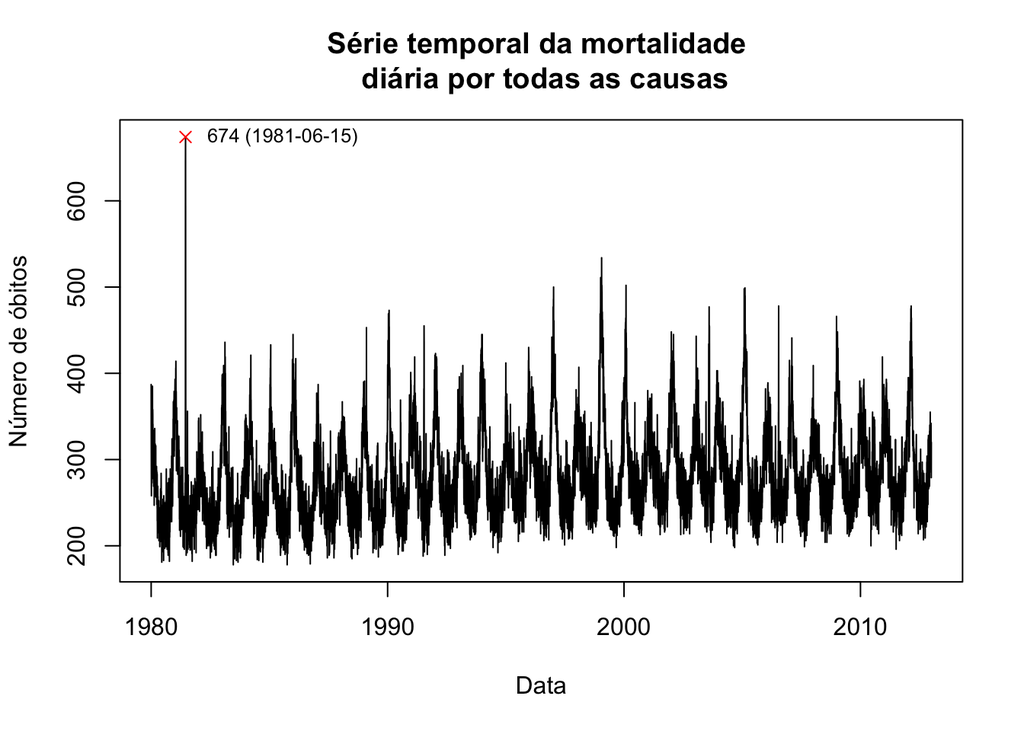

```r
plot(dados$Total~dados$Data,
     type="l",
     main="Série temporal da mortalidade \n diária por todas as causas",
     ylab="Número de óbitos",
     xlab="Data")
points(x = subset(dados,dados$Total==max(dados$Total))$Data,
       y=subset(dados,dados$Total==max(dados$Total))$Total,col="red",pch=4)
text(x = subset(dados,dados$Total==max(dados$Total))$Data+1500,
     y=subset(dados,dados$Total==max(dados$Total))$Total,
     labels = paste0(max(dados$Total)," (",subset(dados,dados$Total==max(dados$Total))$Data,")"),cex=0.8)
```

# Vamos restringir a serie entre entre 1989 e 1993 para estimarmos os excessos associados à onda de calor posteriormente

```r
dados <- subset(dados,dados$Data>=as.Date("1989-01-01") &
                  dados$Data<=as.Date("1993-12-31"))
```

# ver primeiros e ultimos registos da nova serie a confirmar que foi restringida

```r
head(dados,3)
```

```
##            Data Total CircResp
## 3289 1989-01-01   374      230
## 3290 1989-01-02   379      229
## 3291 1989-01-03   363      224
```

```r
tail(dados,3)
```

```
##            Data Total CircResp
## 5112 1993-12-29   387      235
## 5113 1993-12-30   396      232
## 5114 1993-12-31   374      221
```

# criar a variavel tempo

```r
dados$t <- seq(1,nrow(dados),1)
```

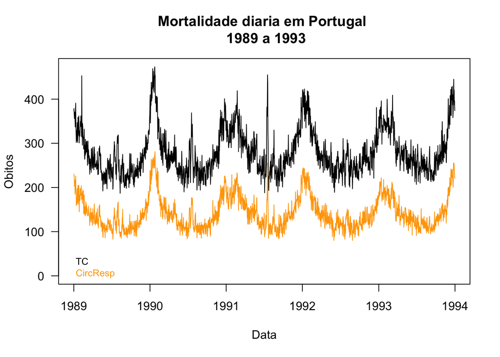

```r
plot(dados$Total~dados$Data,type="l",main="Mortalidade diaria em Portugal \n 1989 a 1993",
     ylim=c(0,max(dados$Total)),ylab="Obitos",xlab="Data",las=1)

lines(dados$CircResp~dados$Data,col="orange")
legend("bottomleft",legend = c("TC", "CircResp"),text.col = c(1,"orange"),horiz = F,bty = "n",cex = 0.8)
```

## Vamos usar um Serfling Model citado em inumeros artigos

# Serfling Model - https://www.ncbi.nlm.nih.gov/pmc/articles/PMC1915276/

```r
t <- seq(1,nrow(dados),1)
t2 <- t^2
t3 <- t^3
sin365 <- sin(2*pi*t/365)
cos365 <- cos(2*pi*t/365)
```

# confirmação do período a usar

```r
library(season)
modTen <- lm(dados$Total ~ t)
```

# summary(modTen)

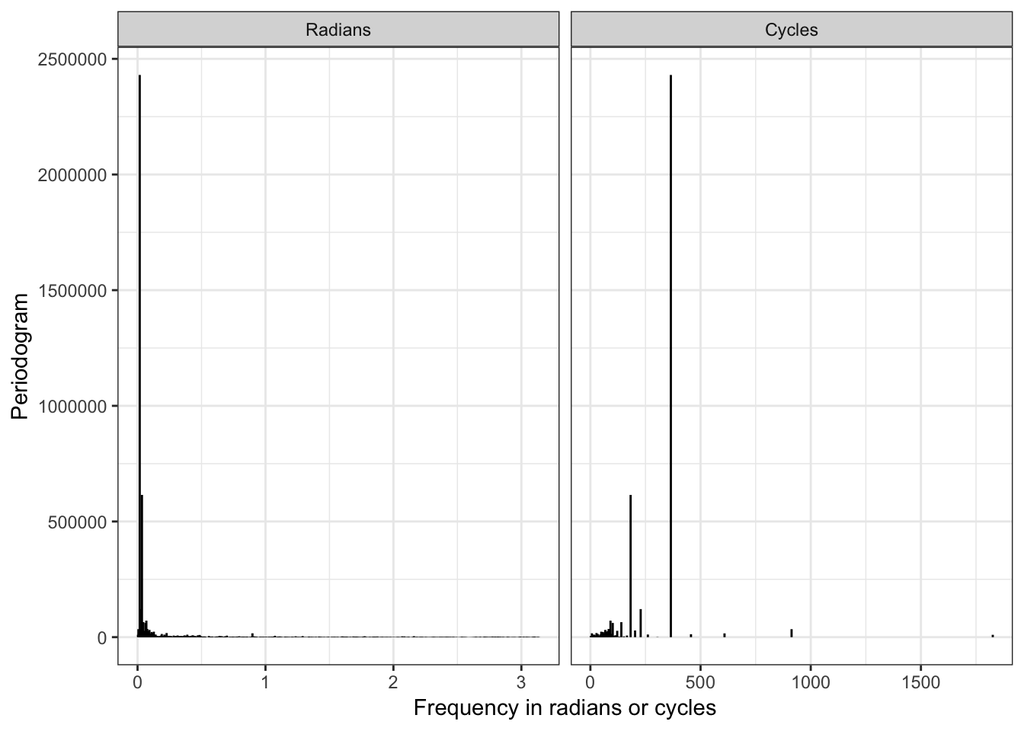

```r
p <- data.frame(peri(dados$Total-modTen$fitted.values,adjmean=TRUE,plot=TRUE))
```

```r
p[order(-p$amp),][1:5,c("c","amp")] # ver os cinco periodos com maior energia (+/- 1 ano e 6 meses)
```

```
##           c       amp
## 6  365.2000 51.593477
## 11 182.6000 25.951529
## 9  228.2500 11.529539
## 21  91.3000  8.831709
## 14 140.4615  8.431515
```

```r
modTen <- lm(dados$CircResp ~ t)
summary(modTen)
```

```
##
## Call:
## lm(formula = dados$CircResp ~ t)
##
## Residuals:
##     Min      1Q  Median      3Q     Max
## -63.196 -26.843  -8.748  20.173 139.654
##
## Coefficients:
##              Estimate Std. Error t value Pr(>|t|)
## (Intercept) 1.406e+02  1.716e+00  81.936   <2e-16 ***
## t           1.956e-03  1.627e-03   1.202    0.229
## ---
## Signif. codes:  0 '***' 0.001 '**' 0.01 '*' 0.05 '.' 0.1 ' ' 1
##
## Residual standard error: 36.64 on 1824 degrees of freedom
## Multiple R-squared:  0.0007916,  Adjusted R-squared:  0.0002438
## F-statistic: 1.445 on 1 and 1824 DF,  p-value: 0.2295
```

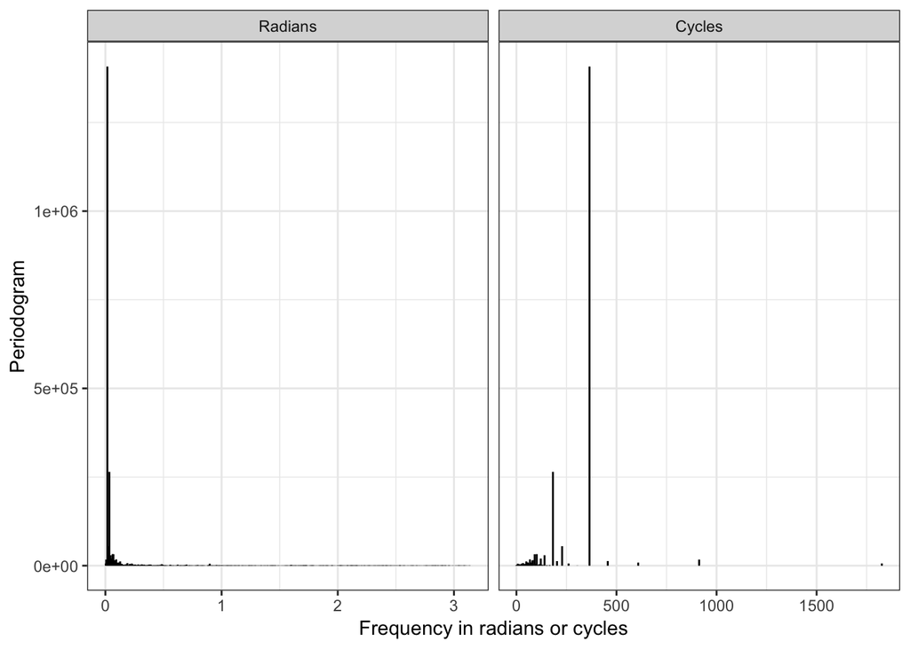

```r
p <- data.frame(peri(dados$CircResp-modTen$fitted.values,adjmean=TRUE,plot=TRUE))
```

```r
p[order(-p$amp),][1:5,c("c","amp")] # ver os cinco periodos com maior energia (+/- 1 ano e 6 meses)
```

```
##           c       amp
## 6  365.2000 39.266734
## 11 182.6000 17.021362
## 9  228.2500  7.766540
## 19 101.4444  5.977408
## 21  91.3000  5.949101
```

```r
mod <- lm(dados$CircResp~ t + t2 + t3 + sin365+cos365)
summary(mod)
```

```
##
## Call:
## lm(formula = dados$CircResp ~ t + t2 + t3 + sin365 + cos365)
##
## Residuals:
##     Min      1Q  Median      3Q     Max
## -51.080 -15.687  -3.149  12.076 150.981
##
## Coefficients:
##               Estimate Std. Error t value Pr(>|t|)
## (Intercept)  1.250e+02  2.263e+00  55.261  < 2e-16 ***
## t            7.831e-02  1.073e-02   7.296 4.42e-13 ***
## t2          -9.444e-05  1.365e-05  -6.919 6.26e-12 ***
## t3           3.335e-08  4.914e-09   6.787 1.54e-11 ***
## sin365       1.971e+01  8.097e-01  24.342  < 2e-16 ***
## cos365       3.488e+01  7.794e-01  44.756  < 2e-16 ***
## ---
## Signif. codes:  0 '***' 0.001 '**' 0.01 '*' 0.05 '.' 0.1 ' ' 1
##
## Residual standard error: 23.54 on 1820 degrees of freedom
## Multiple R-squared:  0.5886, Adjusted R-squared:  0.5875
## F-statistic: 520.9 on 5 and 1820 DF,  p-value: < 2.2e-16
```

# novos dados

```r
newdata<-data.frame(t=t,t2=t2,t3=t3,sin365=sin365,cos365=cos365)
head(newdata)
```

```
##   t t2  t3     sin365    cos365
## 1 1  1   1 0.01721336 0.9998518
## 2 2  4   8 0.03442161 0.9994074
## 3 3  9  27 0.05161967 0.9986668
## 4 4 16  64 0.06880243 0.9976303
## 5 5 25 125 0.08596480 0.9962982
## 6 6 36 216 0.10310170 0.9946708
```

```r
esperado <- data.frame("fit"=predict(mod,newdata,interval="prediction",level = 0.95)[,1],
                       "lwr95"=predict(mod,newdata,interval="prediction",level = 0.95)[,2],
                       "upr95"=predict(mod,newdata,interval="prediction",level = 0.95)[,3],
                       "lwr99"=predict(mod,newdata,interval="prediction",level = 0.99)[,2],
                       "upr99"=predict(mod,newdata,interval="prediction",level = 0.99)[,3])
head(esperado)
```

```
##        fit    lwr95    upr95    lwr99    upr99
## 1 160.3372 113.9412 206.7332  99.3391 221.3353
## 2 160.7389 114.3452 207.1326  99.7438 221.7339
## 3 161.1298 114.7384 207.5213 100.1377 222.1219
## 4 161.5100 115.1208 207.8992 100.5209 222.4991
## 5 161.8792 115.4923 208.2662 100.8930 222.8654
## 6 162.2375 115.8527 208.6222 101.2542 223.2208
```

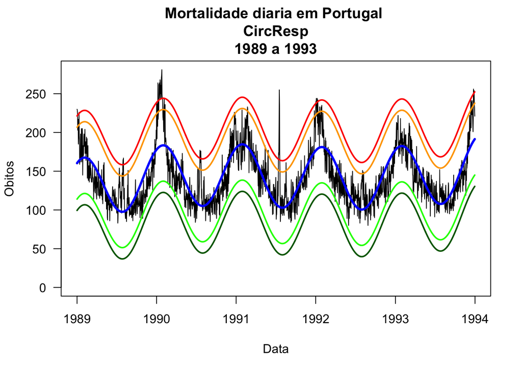

```r
plot(dados$CircResp~dados$Data,type="l",main="Mortalidade diaria em Portugal \n CircResp \n1989 a 1993",
     ylab="Obitos",xlab="Data",las=1,ylim=c(0,max(dados$CircResp)))
lines(esperado$fit~dados$Data,col="blue",lwd=3)
lines(esperado$upr95~dados$Data,col="orange",lwd=2)
lines(esperado$upr99~dados$Data,col="red",lwd=2)
lines(esperado$lwr95~dados$Data,col="green",lwd=2)
lines(esperado$lwr99~dados$Data,col="darkgreen",lwd=2)
```

# vamos juntar a base original (observados) com os esperados

# para ver quais os dias acima dos 95 % de confiança para retirarmos da série

```r
base <- data.frame("Data"=dados$Data,"CircResp"=dados$CircResp,
                   "Esperado"=esperado$fit,"LimiteSuperior95"=esperado$upr95)

head(base)
```

```
##         Data CircResp Esperado LimiteSuperior95
## 1 1989-01-01      230 160.3372         206.7332
## 2 1989-01-02      229 160.7389         207.1326
## 3 1989-01-03      224 161.1298         207.5213
## 4 1989-01-04      203 161.5100         207.8992
## 5 1989-01-05      209 161.8792         208.2662
## 6 1989-01-06      217 162.2375         208.6222
```

# Criar uma nova variavel onde retiramos os dias cujas observaçoes foram superiores ao Limite superior 95%

```r
base$CircResp_new <- ifelse(base$CircResp<base$LimiteSuperior95,
                            base$CircResp,NA)
```

# Ajustar modelo a nova serie

```r
mod1 <- lm(base$CircResp_new ~ t + t2 + t3 + sin365+cos365)
summary(mod1)
```

```
##
## Call:
## lm(formula = base$CircResp_new ~ t + t2 + t3 + sin365 + cos365)
##
## Residuals:
##     Min      1Q  Median      3Q     Max
## -48.616 -12.835  -1.239  11.696  54.347
##
## Coefficients:
##               Estimate Std. Error t value Pr(>|t|)
## (Intercept)  1.231e+02  1.863e+00  66.085  < 2e-16 ***
## t            5.674e-02  8.872e-03   6.395 2.06e-10 ***
## t2          -6.089e-05  1.131e-05  -5.385 8.22e-08 ***
## t3           2.091e-08  4.080e-09   5.125 3.31e-07 ***
## sin365       1.931e+01  6.485e-01  29.783  < 2e-16 ***
## cos365       3.268e+01  6.456e-01  50.628  < 2e-16 ***
## ---
## Signif. codes:  0 '***' 0.001 '**' 0.01 '*' 0.05 '.' 0.1 ' ' 1
##
## Residual standard error: 18.65 on 1731 degrees of freedom
##   (89 observations deleted due to missingness)
## Multiple R-squared:  0.6637, Adjusted R-squared:  0.6627
## F-statistic: 683.2 on 5 and 1731 DF,  p-value: < 2.2e-16
```

```r
esperado1 <- data.frame("fit"=predict(mod1,newdata,interval="prediction",level = 0.95)[,1],
                       "lwr95"=predict(mod1,newdata,interval="prediction",level = 0.95)[,2],
                       "upr95"=predict(mod1,newdata,interval="prediction",level = 0.95)[,3],
                       "lwr99"=predict(mod1,newdata,interval="prediction",level = 0.99)[,2],
                       "upr99"=predict(mod1,newdata,interval="prediction",level = 0.99)[,3])
head(esperado1)
```

```
##        fit    lwr95    upr95    lwr99    upr99
## 1 156.1503 119.3671 192.9336 107.7895 204.5112
## 2 156.5247 119.7435 193.3060 108.1664 204.8830
## 3 156.8891 120.1098 193.6684 108.5334 205.2449
## 4 157.2434 120.4660 194.0208 108.8902 205.5966
## 5 157.5875 120.8120 194.3630 109.2368 205.9382
## 6 157.9214 121.1478 194.6950 109.5731 206.2696
```

# juntando as bases temos:

```r
base1 <- data.frame("Data"=dados$Data,"CircResp"=dados$CircResp,
                    "Esperado"=esperado1$fit,"LimiteSuperior95"=esperado1$upr95,
                    "LimiteSuperior99"=esperado1$upr99)

head(base1)
```

```
##         Data CircResp Esperado LimiteSuperior95 LimiteSuperior99
## 1 1989-01-01      230 156.1503         192.9336         204.5112
## 2 1989-01-02      229 156.5247         193.3060         204.8830
## 3 1989-01-03      224 156.8891         193.6684         205.2449
## 4 1989-01-04      203 157.2434         194.0208         205.5966
## 5 1989-01-05      209 157.5875         194.3630         205.9382
## 6 1989-01-06      217 157.9214         194.6950         206.2696
```

```r
base1$excesso <- ifelse(base1$CircResp<base1$LimiteSuperior95,
                        0,base1$CircResp-base1$Esperado)
```

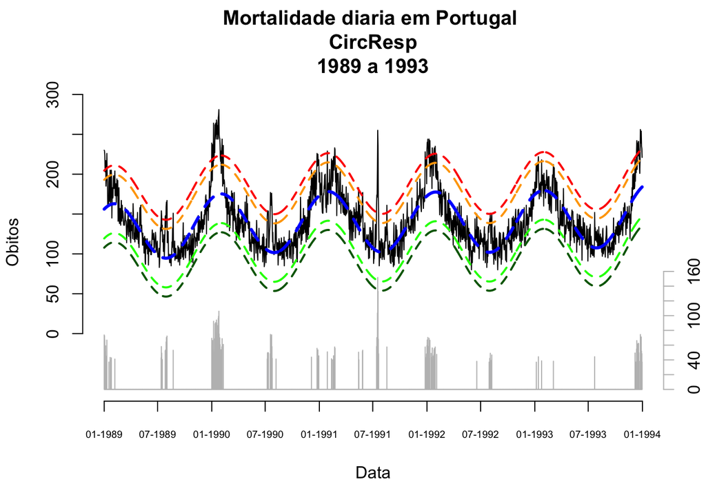

```r
plot(base1$CircResp~base1$Data,type="l",main="Mortalidade diaria em Portugal \n CircResp \n1989 a 1993",
     ylab="Obitos",xlab="Data",las=1,ylim=c(-70,300),axes=F)
axis.Date(1,at=seq(min(base1$Data),max(base1$Data)+1,by="6 months"),format="%m-%Y",cex.axis=0.6)
axis(2,seq(0,300,50))
lines(esperado1$fit~base1$Data,col="blue",lwd=3,lty=2)
lines(esperado1$upr95~base1$Data,col="orange",lwd=2,lty=2)
lines(esperado1$upr99~base1$Data,col="red",lwd=2,lty=2)
lines(esperado1$lwr95~base1$Data,col="green",lwd=2,lty=2)
lines(esperado1$lwr99~base1$Data,col="darkgreen",lwd=2,lty=2)
par(new=T)
plot(base1$excesso~base1$Data,type="h",ylim=c(0,400),col="grey",axes=F,ylab="",xlab="")
axis(4,seq(0,160,20),col="grey")
```

# como o que nos importa e a onda de calor de 1991 que decorreu em julho vamos

# restringir a esse periodo

# sugiro que guardem a base e depois a trabalhem em excel para o calculo dos excessos propriamente ditos

```r
base2 <- subset(base1,base1$Data>="1991-07-01" & base1$Data<="1991-07-31")
```

# sugiro que guardem a base e depois a trabalhem em excel para o calculo dos excessos propriamente ditos

# write.csv2(base1,“Julho1991.csv”,row.names = F)

```r
base2$Excesso <- ifelse(base2$CircResp>base2$LimiteSuperior95,floor(base2$CircResp-base2$Esperado),NA)
```

# Total de excesso

```r
sum(base2$Excesso,na.rm=T)
```

```
## [1] 697
```

# plot do mes de julho

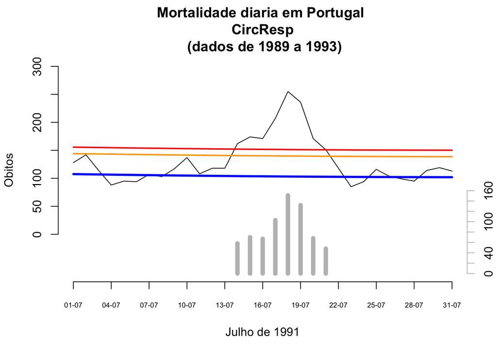

```r
plot(base2$CircResp~base2$Data,type="l",main="Mortalidade diaria em Portugal \n CircResp \n (dados de 1989 a 1993)",
     ylab="Obitos",xlab="Julho de 1991",las=1,ylim=c(-70,300),axes=F)
axis.Date(1,at=seq(min(base2$Data),max(base2$Data)+1,by="3 days"),format="%d-%m",cex.axis=0.6)
axis(2,seq(0,300,50))
lines(base2$Esperado~base2$Data,col="blue",lwd=3)
lines(base2$LimiteSuperior95~base2$Data,col="orange",lwd=2)
lines(base2$LimiteSuperior99~base2$Data,col="red",lwd=2)
par(new=T)
plot(base2$Excesso~base2$Data,type="h", lwd = 6,ylim=c(0,400),col="grey",axes=F,ylab="",xlab="")
axis(4,seq(0,160,20),col="grey")
```

## remover todos os objetos existentes para inciarmos nova analise

```r
rm(list=ls())
```

##### Modelo Linear aplicado a mortalidade semanal

Estudo da epidemia de gripe de 1998/99

dados entre 1995 e 2002

# Definir directoria do trabalho

```r
setwd("~/Desktop/INSA")
```

# Ler o ficheiro de dados formato .csv

```r
dados <- read.csv("Portugal_GC_CR.csv", header = T, sep = ";")
str(dados)
```

```
## 'data.frame':    12054 obs. of  3 variables:
##  $ Data    : Factor w/ 12054 levels "01-01-1980","01-01-1981",..: 1 397 793 1189 1585 1981 2377 2773 3169 3565 ...
##  $ Total   : int  387 340 312 278 258 301 298 302 331 281 ...
##  $ CircResp: int  186 166 180 153 132 164 166 156 170 136 ...
```

# so precisamos corrigir a variavel Data para o tipo Data

```r
dados$Data <- as.Date(dados$Data,format="%d-%m-%Y")
```

# criar a variavel Semana

```r
library(ISOweek)
dados$ISOweek <- ISOweek(dados$Data)
```

# Vamos restringir a serie entre entre 1995 e 2002 para estimarmos os excessos da epidemia posteriormente

```r
dados <- subset(dados,dados$ISOweek>=ISOweek("1995-01-01") &
                  dados$ISOweek<=ISOweek("2002-12-31"))
```

# ver primeiros e ultimos registos da nova serie a confirmar que foi restringida

```r
head(dados,3);tail(dados,3)
```

```
##            Data Total CircResp  ISOweek
## 5474 1994-12-26   352      175 1994-W52
## 5475 1994-12-27   351      167 1994-W52
## 5476 1994-12-28   373      210 1994-W52
```

```
##            Data Total CircResp  ISOweek
## 8404 2003-01-03   335      165 2003-W01
## 8405 2003-01-04   297      148 2003-W01
## 8406 2003-01-05   329      172 2003-W01
```

# Criar a base semanal

```r
dados <- aggregate(x = dados[,c("Total","CircResp")],
                   by = list(dados$ISOweek),sum)
head(dados)
```

```
##    Group.1 Total CircResp
## 1 1994-W52  2578     1351
## 2 1995-W01  2370     1260
## 3 1995-W02  2256     1187
## 4 1995-W03  2277     1249
## 5 1995-W04  2179     1159
## 6 1995-W05  2104     1062
```

```r
colnames(dados) <- c("ISOweek","Total","CircResp")
```

# criar a variavel tempo

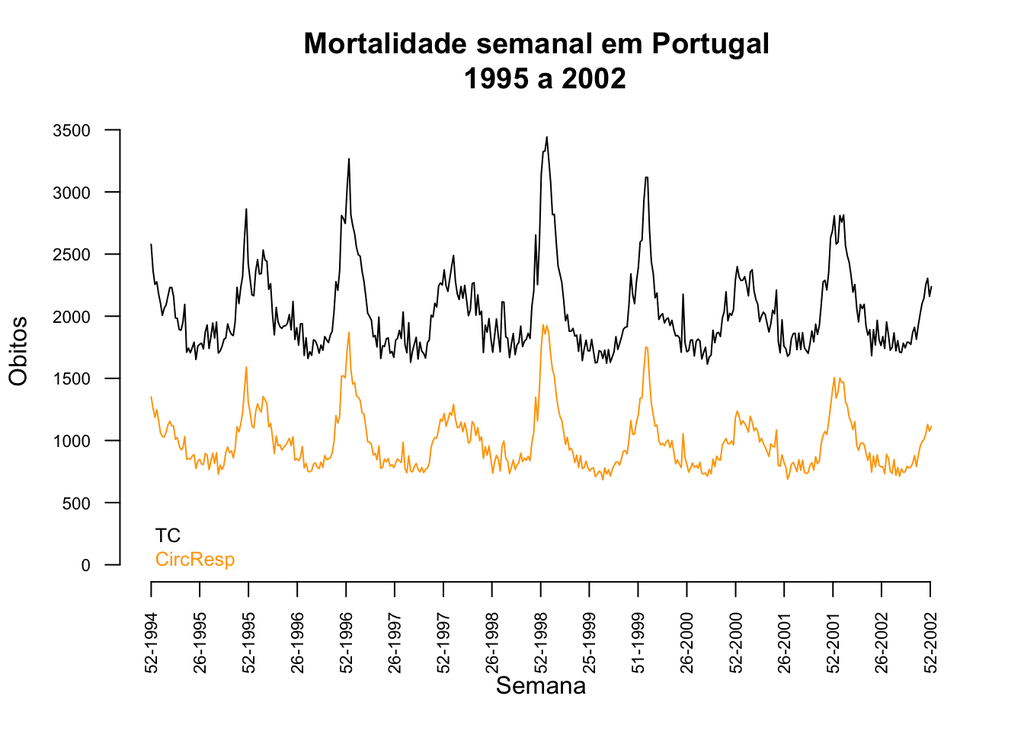

```r
dados$t <- seq(1,nrow(dados),1)
dados$Data <- ISOweek2date(paste0(dados$ISOweek,"-1"))

plot(dados$Total~dados$Data,type="l",main="Mortalidade semanal em Portugal \n 1995 a 2002",
     ylim=c(0,max(dados$Total)),ylab="Obitos",xlab="Semana",las=1,axes="F")
axis(2,cex.axis=0.7,las=1)
axis.Date(1,at=seq(min(dados$Data),max(dados$Data),by="6 months"),format="%V-%Y",cex.axis=0.7,las=2)
lines(dados$CircResp~dados$Data,col="orange")
legend("bottomleft",legend = c("TC", "CircResp"),text.col = c(1,"orange"),horiz = F,bty = "n",cex = 0.8)
```

# Serfling Model - https://www.ncbi.nlm.nih.gov/pmc/articles/PMC1915276/

```r
t <- seq(1,nrow(dados),1)
t2 <- t^2
t3 <- t^3
sin52 <- sin(2*pi*t/52)
cos52 <- cos(2*pi*t/52)
```

```r
library(season)
modTen <- lm(dados$CircResp ~ t)
summary(modTen)
```

```
##
## Call:
## lm(formula = dados$CircResp ~ t)
##
## Residuals:
##     Min      1Q  Median      3Q     Max
## -297.21 -171.19  -62.06  114.99  942.02
##
## Coefficients:
##               Estimate Std. Error t value Pr(>|t|)
## (Intercept) 1033.62490   23.00491  44.931   <2e-16 ***
## t             -0.21157    0.09493  -2.229   0.0264 *
## ---
## Signif. codes:  0 '***' 0.001 '**' 0.01 '*' 0.05 '.' 0.1 ' ' 1
##
## Residual standard error: 235 on 417 degrees of freedom
## Multiple R-squared:  0.01177,    Adjusted R-squared:  0.009402
## F-statistic: 4.967 on 1 and 417 DF,  p-value: 0.02636
```

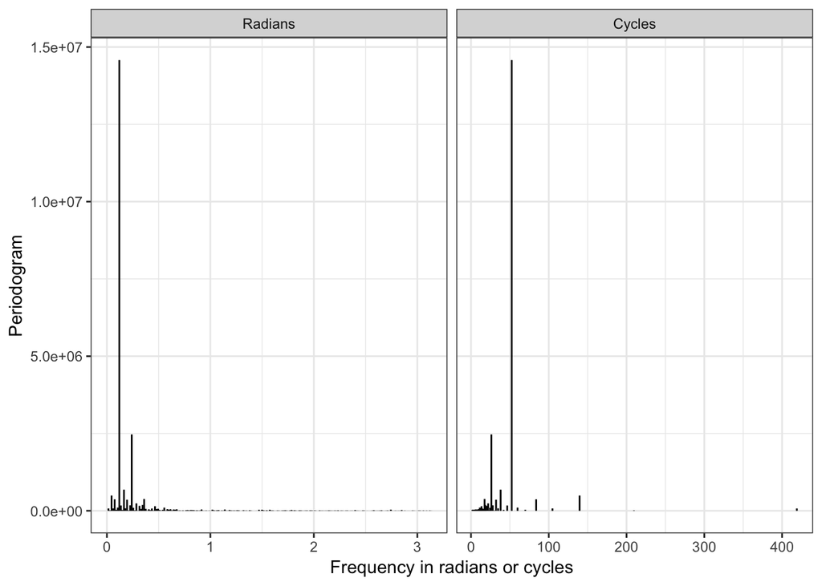

```r
p <- data.frame(peri(dados$CircResp-modTen$fitted.values,adjmean=TRUE,plot=TRUE))
```

```r
p[order(-p$amp),][1:5,c("c","amp")] # ver os cinco periodos com maior energia (+/- 1 ano e 6 meses)
```

```
##            c       amp
## 9   52.37500 263.79490
## 17  26.18750 108.56759
## 12  38.09091  57.06006
## 4  139.66667  48.54850
## 25  17.45833  42.63240
```

```r
mod <- lm(dados$CircResp~ t + t2 + t3 + sin52+cos52)
summary(mod)
```

```
##
## Call:
## lm(formula = dados$CircResp ~ t + t2 + t3 + sin52 + cos52)
##
## Residuals:
##     Min      1Q  Median      3Q     Max
## -250.72  -90.41  -26.46   61.71  682.84
##
## Coefficients:
##               Estimate Std. Error t value Pr(>|t|)
## (Intercept)  9.518e+02  2.859e+01  33.288   <2e-16 ***
## t            1.102e+00  5.890e-01   1.870   0.0621 .
## t2          -5.233e-03  3.256e-03  -1.607   0.1088
## t3           6.050e-06  5.098e-06   1.187   0.2360
## sin52        1.858e+02  1.009e+01  18.411   <2e-16 ***
## cos52        1.863e+02  9.912e+00  18.794   <2e-16 ***
## ---
## Signif. codes:  0 '***' 0.001 '**' 0.01 '*' 0.05 '.' 0.1 ' ' 1
##
## Residual standard error: 143.7 on 413 degrees of freedom
## Multiple R-squared:  0.6341, Adjusted R-squared:  0.6297
## F-statistic: 143.1 on 5 and 413 DF,  p-value: < 2.2e-16
```

# novos dados

```r
newdata<-data.frame(t=t,t2=t2,t3=t3,sin52=sin52,cos52=cos52)
head(newdata)
```

```
##   t t2  t3     sin52     cos52
## 1 1  1   1 0.1205367 0.9927089
## 2 2  4   8 0.2393157 0.9709418
## 3 3  9  27 0.3546049 0.9350162
## 4 4 16  64 0.4647232 0.8854560
## 5 5 25 125 0.5680647 0.8229839
## 6 6 36 216 0.6631227 0.7485107
```

```r
esperado <- data.frame("fit"=predict(mod,newdata,interval="prediction",level = 0.95)[,1],
                       "lwr95"=predict(mod,newdata,interval="prediction",level = 0.95)[,2],
                       "upr95"=predict(mod,newdata,interval="prediction",level = 0.95)[,3],
                       "lwr99"=predict(mod,newdata,interval="prediction",level = 0.99)[,2],
                       "upr99"=predict(mod,newdata,interval="prediction",level = 0.99)[,3])
head(esperado)
```

```
##        fit    lwr95    upr95    lwr99    upr99
## 1 1160.218 871.7637 1448.671 780.4814 1539.954
## 2 1179.318 891.1110 1467.524 799.9069 1558.728
## 3 1195.121 907.1512 1483.092 816.0220 1574.221
## 4 1207.414 919.6692 1495.159 828.6112 1586.217
## 5 1216.032 928.5007 1503.563 837.5104 1594.553
## 6 1220.864 933.5352 1508.193 842.6088 1599.120
```

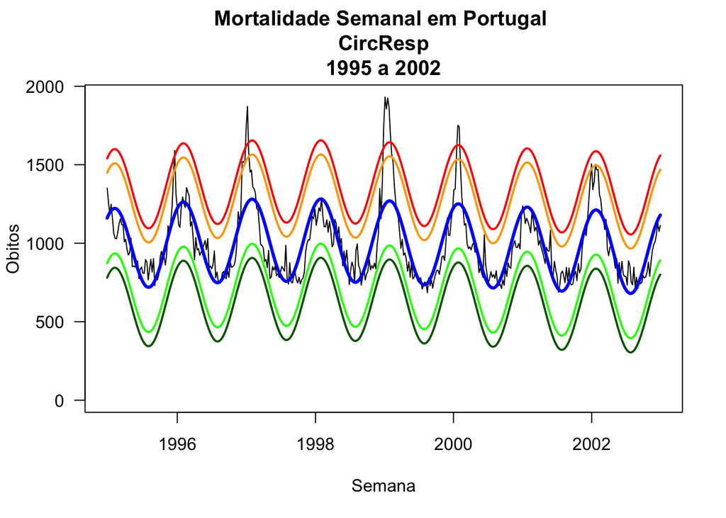

```r
plot(dados$CircResp~dados$Data,type="l",main="Mortalidade Semanal em Portugal \n CircResp \n1995 a 2002",
     ylab="Obitos",xlab="Semana",las=1,ylim=c(0,max(dados$CircResp)))

lines(esperado$fit~dados$Data,col="blue",lwd=3)
lines(esperado$upr95~dados$Data,col="orange",lwd=2)
lines(esperado$upr99~dados$Data,col="red",lwd=2)
lines(esperado$lwr95~dados$Data,col="green",lwd=2)
lines(esperado$lwr99~dados$Data,col="darkgreen",lwd=2)
```

# vamos juntar a base original (observados) com os esperados

# para ver quais os dias acima dos 95 % de confiança para retiramos da serie

```r
base <- data.frame("ISOweek"=dados$ISOweek,"Data"=dados$Data,"CircResp"=dados$CircResp,
                   "Esperado"=esperado$fit,"LimiteSuperior95"=esperado$upr95)

head(base)
```

```
##    ISOweek       Data CircResp Esperado LimiteSuperior95
## 1 1994-W52 1994-12-26     1351 1160.218         1448.671
## 2 1995-W01 1995-01-02     1260 1179.318         1467.524
## 3 1995-W02 1995-01-09     1187 1195.121         1483.092
## 4 1995-W03 1995-01-16     1249 1207.414         1495.159
## 5 1995-W04 1995-01-23     1159 1216.032         1503.563
## 6 1995-W05 1995-01-30     1062 1220.864         1508.193
```

# Criar uma nova variavel onde retiramos os dias cujas observaçoes foram superiores ao Limite superior 95%

```r
base$CircResp_new <- ifelse(base$CircResp<base$LimiteSuperior95,
                            base$CircResp,NA)
```

# Ajustar modelo a nova serie

```r
mod1 <- lm(base$CircResp_new ~ t + t2 + t3 + sin52 + cos52)
summary(mod1)
```

```
##
## Call:
## lm(formula = base$CircResp_new ~ t + t2 + t3 + sin52 + cos52)
##
## Residuals:
##     Min      1Q  Median      3Q     Max
## -214.38  -62.73  -14.23   50.22  352.99
##
## Coefficients:
##               Estimate Std. Error t value Pr(>|t|)
## (Intercept)  9.714e+02  1.983e+01  48.994   <2e-16 ***
## t            3.369e-01  4.110e-01   0.820    0.413
## t2          -2.371e-03  2.274e-03  -1.043    0.298
## t3           3.375e-06  3.559e-06   0.948    0.344
## sin52        1.652e+02  7.058e+00  23.404   <2e-16 ***
## cos52        1.477e+02  7.090e+00  20.827   <2e-16 ***
## ---
## Signif. codes:  0 '***' 0.001 '**' 0.01 '*' 0.05 '.' 0.1 ' ' 1
##
## Residual standard error: 99.23 on 395 degrees of freedom
##   (18 observations deleted due to missingness)
## Multiple R-squared:  0.7139, Adjusted R-squared:  0.7103
## F-statistic: 197.1 on 5 and 395 DF,  p-value: < 2.2e-16
```

```r
esperado1 <- data.frame("fit"=predict(mod1,newdata,interval="prediction",level = 0.95)[,1],
                        "lwr95"=predict(mod1,newdata,interval="prediction",level = 0.95)[,2],
                        "upr95"=predict(mod1,newdata,interval="prediction",level = 0.95)[,3],
                        "lwr99"=predict(mod1,newdata,interval="prediction",level = 0.99)[,2],
                        "upr99"=predict(mod1,newdata,interval="prediction",level = 0.99)[,3])
```

```r
head(esperado1)
```

```
##        fit    lwr95    upr95    lwr99    upr99
## 1 1138.203 938.9559 1337.449 875.8832 1400.522
## 2 1154.940 955.8627 1354.017 892.8438 1417.036
## 3 1169.005 970.0909 1367.919 907.1235 1430.886
## 4 1180.198 981.4399 1378.956 918.5218 1441.874
## 5 1188.361 989.7509 1386.970 926.8799 1449.841
## 6 1193.378 994.9094 1391.847 932.0829 1454.673
```

# juntando as bases temos:

```r
base1 <- data.frame("ISOweek"=dados$ISOweek, "Data"=dados$Data,"CircResp"=dados$CircResp,
                    "Esperado"=esperado1$fit,"LimiteSuperior95"=esperado1$upr95,
                    "LimiteSuperior99"=esperado1$upr99)

head(base1)
```

```
##    ISOweek       Data CircResp Esperado LimiteSuperior95 LimiteSuperior99
## 1 1994-W52 1994-12-26     1351 1138.203         1337.449         1400.522
## 2 1995-W01 1995-01-02     1260 1154.940         1354.017         1417.036
## 3 1995-W02 1995-01-09     1187 1169.005         1367.919         1430.886
## 4 1995-W03 1995-01-16     1249 1180.198         1378.956         1441.874
## 5 1995-W04 1995-01-23     1159 1188.361         1386.970         1449.841
## 6 1995-W05 1995-01-30     1062 1193.378         1391.847         1454.673
```

```r
base1$excesso <- ifelse(base1$CircResp<base1$LimiteSuperior95,
                        NA,base1$CircResp-base1$Esperado)
```

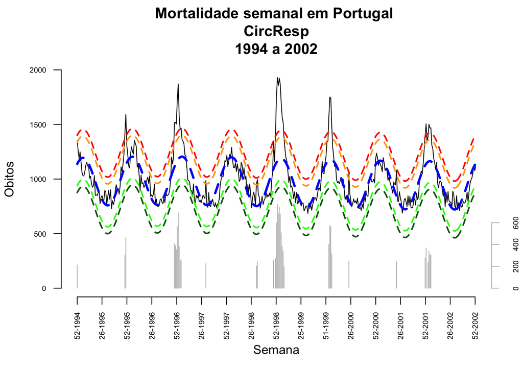

```r
plot(base1$CircResp~base1$Data,type="l",main="Mortalidade semanal em Portugal \n CircResp \n1994 a 2002",
     ylab="Obitos",xlab="Semana",las=1,ylim=c(0,2000),axes=F)
axis.Date(1,at=seq(min(base1$Data),max(base1$Data)+1,by="6 months"),format="%V-%Y",cex.axis=0.6,las=2)
axis(2,seq(0,2000,500),las=1,cex.axis=0.6)
lines(esperado1$fit~base1$Data,col="blue",lwd=3,lty=2)
lines(esperado1$upr95~base1$Data,col="orange",lwd=2,lty=2)
lines(esperado1$upr99~base1$Data,col="red",lwd=2,lty=2)
lines(esperado1$lwr95~base1$Data,col="green",lwd=2,lty=2)
lines(esperado1$lwr99~base1$Data,col="darkgreen",lwd=2,lty=2)
par(new=T)
plot(base1$excesso~base1$Data,type="h",ylim=c(0,2000),col="grey",axes=F,ylab="",xlab="")
axis(4,seq(0,600,200),col="grey",cex.axis=0.6)
```

# como o que nos importa e a epidemia de 98/99 vamos

# restringir a esse periodo

# sugiro que guardem a base e depois a trabalhem em excel para o calculo dos excessos propriamente ditos

```r
base2 <- subset(base1,base1$Data>=ISOweek2date("1998-W40-1") & base1$Data<=ISOweek2date("1999-W20-1"))
base2
```

```
##      ISOweek       Data CircResp  Esperado LimiteSuperior95
## 197 1998-W40 1998-09-28      803  846.4840         1042.587
## 198 1998-W41 1998-10-05      821  869.2371         1065.349
## 199 1998-W42 1998-10-12      898  893.4783         1089.600
## 200 1998-W43 1998-10-19      831  918.8511         1114.983
## 201 1998-W44 1998-10-26      859  944.9824         1141.126
## 202 1998-W45 1998-11-02      840  971.4884         1167.643
## 203 1998-W46 1998-11-09      873  997.9794         1194.146
## 204 1998-W47 1998-11-16      838 1024.0662         1220.245
## 205 1998-W48 1998-11-23      986 1049.3652         1245.555
## 206 1998-W49 1998-11-30     1065 1073.5046         1269.706
## 207 1998-W50 1998-12-07     1349 1096.1293         1292.340
## 208 1998-W51 1998-12-14     1157 1116.9064         1313.126
## 209 1998-W52 1998-12-21     1407 1135.5297         1331.757
## 210 1998-W53 1998-12-28     1751 1151.7247         1347.957
```

[output cut: 55 more lines]

# sugiro que guardem a base e depois a trabalhem em excel para o calculo dos excessos propriamente ditos

# write.csv2(base1,“Epoca1998_99.csv”,row.names = F)

# Total de excesso

```r
floor(sum(base2$excesso,na.rm=T))
```

```
## [1] 5414
```

# plot da epoca

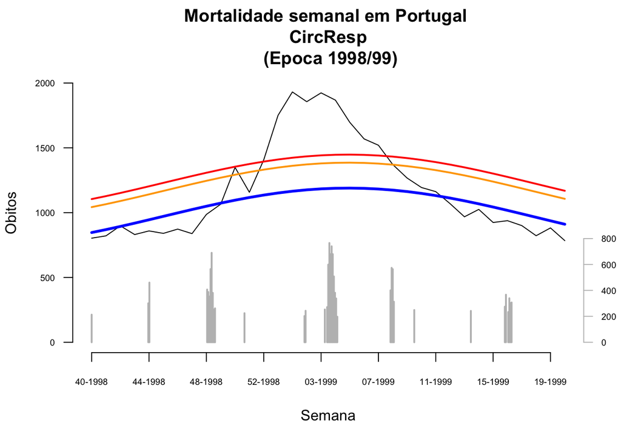

```r
plot(base2$CircResp~base2$Data,type="l",main="Mortalidade semanal em Portugal \n CircResp \n (Epoca 1998/99)",
     ylab="Obitos",xlab="Semana",las=1,ylim=c(0,2000),axes=F)
axis.Date(1,at=seq(min(base2$Data),max(base2$Data)+1,by="4 weeks"),format="%V-%Y",cex.axis=0.6)
axis(2,seq(0,2000,500),cex.axis=0.6,las=1)
lines(base2$Esperado~base2$Data,col="blue",lwd=3)
lines(base2$LimiteSuperior95~base2$Data,col="orange",lwd=2)
lines(base2$LimiteSuperior99~base2$Data,col="red",lwd=2)
par(new=T)
plot(base1$excesso~base1$Data,type="h", lwd = 2,ylim=c(0,2000),col="grey",axes=F,ylab="",xlab="")
axis(4,seq(0,800,200),col="grey",cex.axis=0.6,las=1)
```

##### Suponhamos agora que queremos saber o que esperamos num futuro próximo tendo em conta o historico.

##### Vamos prever usando novos dados relativos ao tempo futuro

# ver o modelo que temos

```r
summary(mod1)
```

```
##
## Call:
## lm(formula = base$CircResp_new ~ t + t2 + t3 + sin52 + cos52)
##
## Residuals:
##     Min      1Q  Median      3Q     Max
## -214.38  -62.73  -14.23   50.22  352.99
##
## Coefficients:
##               Estimate Std. Error t value Pr(>|t|)
## (Intercept)  9.714e+02  1.983e+01  48.994   <2e-16 ***
## t            3.369e-01  4.110e-01   0.820    0.413
## t2          -2.371e-03  2.274e-03  -1.043    0.298
## t3           3.375e-06  3.559e-06   0.948    0.344
## sin52        1.652e+02  7.058e+00  23.404   <2e-16 ***
## cos52        1.477e+02  7.090e+00  20.827   <2e-16 ***
## ---
## Signif. codes:  0 '***' 0.001 '**' 0.01 '*' 0.05 '.' 0.1 ' ' 1
##
## Residual standard error: 99.23 on 395 degrees of freedom
##   (18 observations deleted due to missingness)
## Multiple R-squared:  0.7139, Adjusted R-squared:  0.7103
## F-statistic: 197.1 on 5 and 395 DF,  p-value: < 2.2e-16
```

# definir o periodo total para o qual pretendemos obter valores estimados pelo modelo

```r
t <- seq(1,nrow(dados)+52,1) # vamos estimar um corredor para mais um ano (52 semanas)
t2 <- t^2
t3 <- t^3
sin52 <- sin(2*pi*t/52)
cos52 <- cos(2*pi*t/52)
```

# novos dados

```r
newdata<-data.frame(t=t,t2=t2,t3=t3,sin52=sin52,cos52=cos52)
head(newdata)
```

```
##   t t2  t3     sin52     cos52
## 1 1  1   1 0.1205367 0.9927089
## 2 2  4   8 0.2393157 0.9709418
## 3 3  9  27 0.3546049 0.9350162
## 4 4 16  64 0.4647232 0.8854560
## 5 5 25 125 0.5680647 0.8229839
## 6 6 36 216 0.6631227 0.7485107
```

```r
tail(newdata)
```

```
##       t     t2        t3         sin52     cos52
## 466 466 217156 101194696 -2.393157e-01 0.9709418
## 467 467 218089 101847563 -1.205367e-01 0.9927089
## 468 468 219024 102503232 -2.204364e-15 1.0000000
## 469 469 219961 103161709  1.205367e-01 0.9927089
## 470 470 220900 103823000  2.393157e-01 0.9709418
## 471 471 221841 104487111  3.546049e-01 0.9350162
```

```r
esperado <- data.frame("fit"=predict(mod1,newdata,interval="prediction",level = 0.95)[,1],
                       "lwr95"=predict(mod1,newdata,interval="prediction",level = 0.95)[,2],
                       "upr95"=predict(mod1,newdata,interval="prediction",level = 0.95)[,3],
                       "upr95_CI"=predict(mod1,newdata,interval="confidence",level = 0.95)[,3],
                       "lwr99"=predict(mod1,newdata,interval="prediction",level = 0.99)[,2],
                       "upr99"=predict(mod1,newdata,interval="prediction",level = 0.99)[,3],
                       "upr99_CI"=predict(mod1,newdata,interval="confidence",level = 0.99)[,3])
head(esperado)
```

```
##        fit    lwr95    upr95 upr95_CI    lwr99    upr99 upr99_CI
## 1 1138.203 938.9559 1337.449 1178.736 875.8832 1400.522 1191.567
## 2 1154.940 955.8627 1354.017 1194.630 892.8438 1417.036 1207.194
## 3 1169.005 970.0909 1367.919 1207.870 907.1235 1430.886 1220.173
## 4 1180.198 981.4399 1378.956 1218.257 918.5218 1441.874 1230.305
## 5 1188.361 989.7509 1386.970 1225.637 926.8799 1449.841 1237.436
## 6 1193.378 994.9094 1391.847 1229.895 932.0829 1454.673 1241.455
```

## adicionar indicativo das semanas e dias a base esperados

```r
esperado$Data <- seq.Date(from = min(dados$Data),by="7 days",
                          length.out = nrow(esperado))
esperado$ISOweek <- ISOweek(esperado$Data)
tail(esperado)
```

```
##          fit    lwr95    upr95 upr95_CI    lwr99    upr99 upr99_CI
## 466 1058.845 846.8740 1270.815 1141.762 779.7734 1337.916 1168.010
## 467 1082.008 869.4904 1294.526 1166.314 802.2166 1361.799 1193.001
## 468 1103.329 890.2471 1316.411 1189.047 822.7947 1383.863 1216.182
## 469 1122.501 908.8391 1336.164 1209.652 841.2031 1403.800 1237.240
## 470 1139.251 924.9931 1353.508 1227.851 857.1685 1421.333 1255.898
## 471 1153.338 938.4709 1368.205 1243.402 870.4536 1436.222 1271.912
##           Data  ISOweek
## 466 2003-11-24 2003-W48
## 467 2003-12-01 2003-W49
## 468 2003-12-08 2003-W50
## 469 2003-12-15 2003-W51
## 470 2003-12-22 2003-W52
## 471 2003-12-29 2004-W01
```

# desenhar e estimativa

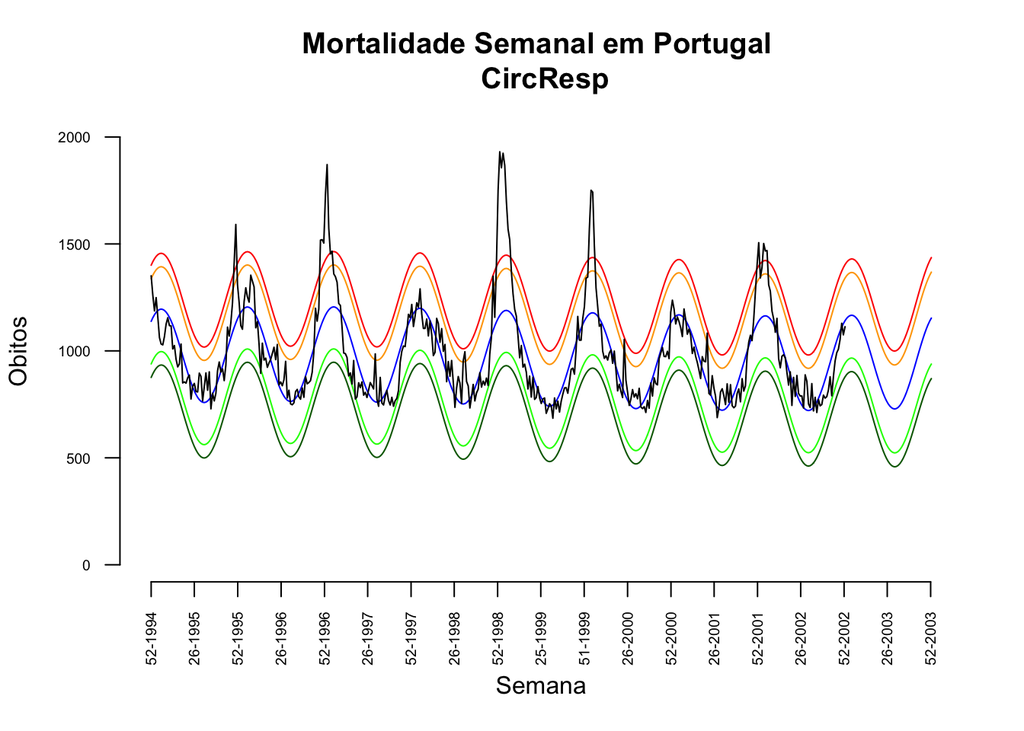

```r
plot(esperado$upr99~esperado$Data,col="red",type="l",ylim=c(0,2000),
     xlab="Semana",ylab="Obitos",las=1,axes=F,
     main="Mortalidade Semanal em Portugal \n CircResp")
axis.Date(1,at=seq(min(esperado$Data),max(esperado$Data)+1,by="6 months"),format="%V-%Y",cex.axis=0.6,las=2)
axis(2,cex.axis=0.6,las=1)
lines(esperado$upr95~esperado$Data,col="orange")
lines(esperado$fit~esperado$Data,col="blue")
lines(esperado$lwr95~esperado$Data,col="green")
lines(esperado$lwr99~esperado$Data,col="darkgreen")
lines(dados$CircResp~dados$Data)
```